# Creating images with R

with a little bit of magick (& HTML)

Mei Chew

```css
h1 {
color: #c8dce0;
font-style: italic;
}
h2 {
font-family: "Lucida Console";
color: #88a690;
}
p {
font-family: "Times New Roman";
}
img {
  margin: auto;
  display: block;
  height: 400px;
}
```

## Project requirements

On Github, Project 1 required us to set up an account. This website is an ideal platform to work within, as each project and their related files can be stored appropriately for continuous use. For this assignment, I have made an account and a corresponding repository for 220. The repository can be found here, where files related to 220 will be uploaded to. A link to the website can be found here. A ‘read me’ markdown file has been included in my repository, to give a short overview of the purpose of the repository and the project. Several markdown syntax methods have been employed in the ‘read me’, to demonstrate my ability to use the markdown language.

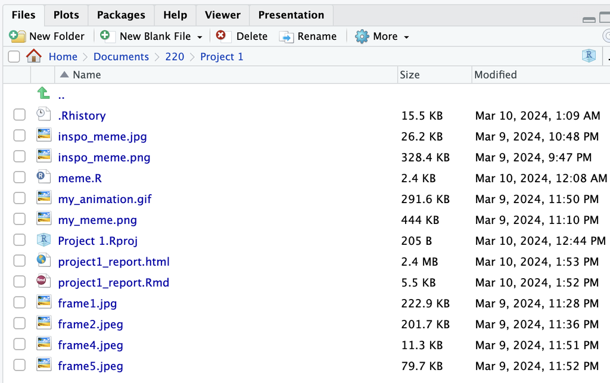

## My meme

Key Components: I decided to retain the image of the hamster, as I believed it quite succintly conveyed the sensation of being ‘shaken’ and of being in shock, disproportionately to what was happening. The text was self-deprecating, so I decided to make a more light-hearted meme.

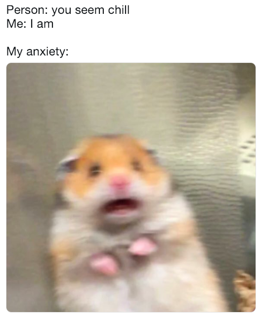

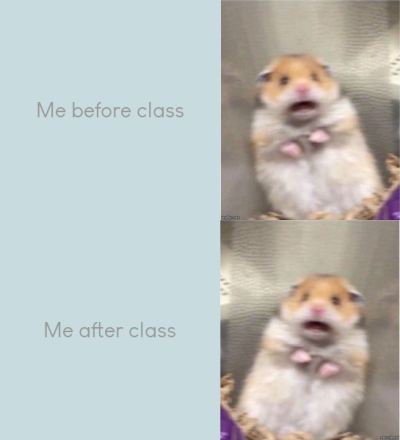

```r
library(magick)
# Create new meme
# Square 1
meme_text = image_blank(width = 300,
                        height = 300,
                        color = '#c8dce0') %>%
  image_annotate(text = 'Me before class',
                 color = '#999999',
                 size = 30,
                 gravity = "Center")

# Square 2
meme_image = image_read(path = "https://a.pinatafarm.com/500x611/7761b37244/scared-hamster.jpg") %>%
  image_scale('x300')

# Square 3
meme_text2 = image_blank(width = 300,
                        height = 300,
                        color = '#c8dce0') %>%
  image_annotate(text = 'Me after class',
                 color = '#999999',
                 size = 30,
                 gravity = "Center")

# Square 4
meme_image2 = image_read(path = "https://a.pinatafarm.com/500x611/7761b37244/scared-hamster.jpg") %>%
  image_flop() %>%
  image_scale('x300')

# Add to a vector
top_row = image_append(c(meme_text, meme_image))
bottom_row = image_append(c(meme_text2, meme_image2))

# Append the images
meme = c(top_row, bottom_row) %>%
  image_append(stack = TRUE) %>%
  image_scale(400)

meme
```

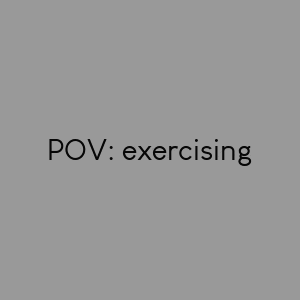

```r
# Animate meme
# Frame 1
gif_text = image_blank(width = 300,
                        height = 300,
                        color = '#999999') %>%
  image_annotate(text = 'POV: exercising',
                 color = '#000000',
                 size = 30,
                 gravity = "Center")

# Frame 2
gif_image2 = image_read(path = "https://i.kym-cdn.com/entries/icons/original/000/046/138/catdriving.jpg") %>%
  image_scale('x350') %>%
  image_crop("300x300+160")

# Frame 3
gif_image3 = image_read(path = "https://pbs.twimg.com/media/GHq8ZywWEAAzxtM?format=jpg&name=medium") %>%
  image_scale('x300')

# Frame 4
gif_image4 = image_read(path = "https://pbs.twimg.com/media/GHq8ZywWEAAzxtM?format=jpg&name=medium") %>%
  image_scale('x300') %>%
  image_flop()

# Frame 5
gif_image5 = image_read(path = "https://pbs.twimg.com/media/GHsN_CpaEAAS_Q-?format=jpg&name=900x900") %>%
  image_scale('x300')

# Frame 6
gif_image6 = image_read(path = "https://pbs.twimg.com/media/GB31IvsbYAAPwhR?format=jpg&name=large") %>%
  image_scale('x300')

# Create a vector
gif_vector = c(gif_text, gif_image2, gif_image3, gif_image4, gif_image5, gif_image6)

# Create the animation
animation = image_animate(gif_vector, fps = 1)
```

## Creativity

I believe that my project conveyed a satisfactory amount of creativity. During the process of creating the meme, I utilised a magick function ‘image_flop()’ that mirrored the meme image, that provided an element of humour that the before and after emotion had not changed, but only been mirrored. During the process of creating the gif, I decided upon storytelling an event of going to the gym, through the theme of cats. Again, I used a magick function to mirror an image, to convey movement of the character within the gif, as if they were actually working out. Additionally, I used the ‘image_crop()’ function to obtain the image I was aiming for, as I could not find exactly the image I wanted to use in a suitable image format. For readability, I scaled the images to same height as the image blanks, and centred them in the css code.

## Learning reflection

An important idea I learnt from this project was the importance of code readability. During the creation of the meme, I was meticulous in variable assignment and labelling of various functions, so that they were more accessible when I was editing the code. The final product of the HTML looked cohesive and readable, so I am satisfied with what I learned.

Data technology will be an ubiquitous sector for the future. Some elements I would like to learn further is the skills and functions surrounding data analysis, and how to effectively communicate findings through data technology. This would be ideally learnt through this course, which I am excited to learn as a continuation of the knowledge base I have built from doing Stats 101 & 201.